# **Probabilidad de que un DataScience busque un cambio de trabajo.**

## Predecir el interés de cambiar su trabajo actual

### Presentado por Luis Hernando Benitez

## **Dataset Utilizado.**

El dataset utilizado *HR Analytics: Job Change of Data Scientists* se encuentra alojado en el siguiente link: https://www.kaggle.com/arashnic/hr-analytics-job-change-of-data-scientists?select=aug_test.csv

- **enrollee_id** : ID único para los candidatos.
- **city**: código de ciudad (no corresponde a ninguna nomenclatura estándar).
- **city_development_index** : índice de desarrollo de la ciudad (escalado).
- **gender**: género del candidato.
- **relevent_experience**: experiencia relevante del candidato.
- **enrolled_university**: tipo de curso universitario inscrito (si lo hay).
- **education_level**: nivel de educación del candidato.
- **major_discipline** : disciplina educativa principal del candidato.
- **experience**: experiencia total del candidato en años.
- **company_size**: número total de empleados en la empresa del empleador actual.
- **company_type** : tipo de compañía empleadora actual.
- **lastnewjob**: diferencia en años entre el trabajo anterior y el actual.
- **training_hours**: horas de formación completadas.
- **target**: 0 –No busca un cambio de trabajo, 1 – Sí busca un cambio de trabajo.

**NOTA**: El archivo utilizado para esta practica es *aug_train.csv*

## **1. Entendimiento del negocio.**

**NOTA:** El siguiente caso y los objetivos se construyen teniendo en cuenta la descripción del dataset original.

### **1.1 Situación actual**

La empresa Simply-Data ofrece servicios de Machine Learning y DataScience, incluyendo cursos de formación profesional.

La empresa desea implementar un programa de contratación para los estudiantes que completan con éxito algunos de sus cursos impartidos. Por ello, Simply-Data desea saber cuáles de los candidatos que aprueban los cursos están buscando una nueva oportunidad laboral en esta u otra empresa. El conocer este dato permite reducir costos en términos de tiempo y dinero, permitiendo mejorar la calidad formativa y categorizar mejor a los candidatos.

Los datos recopilados de los estudiantes incluyen educación, datos demográficos y experiencia.

### **1.2 Objetivos del negocio**

- Identificar los candidatos que presentan mayor probabilidad de buscar un cambio de trabajo o de continuar en esta empresa.
- Comprender los factores que llevan a una persona a dejar su trabajo actual.
- Identificar si variables como el nivel educativo, años de experiencia o género incluyen significativamente en la decisión de cambiar el empleo actual.

### **1.3 Metas del proyecto**

- Identificar mediante un análisis exploratorio las características de la muestra de estudiantes y la naturaleza de las variables.
- Reconocer las relaciones entre las diferentes variables y las correlaciones que tienen con la variable objetivo.
- Presentar visualizaciones de los datos que permitan a la empresa comprender qué factores afectan las decisiones de los candidatos.
- Crear un modelo que permita predecir si un estudiante busca o no un cambio de empleo al culminar su formación.

### **1.4 Planeación del proyecto de análisis de datos**

Para lograr el objetivo principal del proyecto se desarrollaran las siguientes actividades:

1. **Entendimiento de los datos y tratamiento de los datos** Comprende la etapa de adquisición de información y la exploración inicial de los datos.

La limpieza de datos se desarrolla de forma paralela al entendimiento. Se realiza el tratamiento de datos vacíos y otras transformaciones para dar mejor estructura al dataset y usarse en las siguientes etapas.

1. **Análisis estadístico descriptivo de los datos** Durante el análisis descriptivo se profundiza en las variables del dataset, su distribución, rango de valores y correlaciones. Se incluyen visualizaciones estáticas e interactivas, que permiten obtener información relevante del conjunto de datos y formar las primeras hipótesis
1. **Análisis de datos** Durante el análisis de datos se realizan procesos de normalización de los datos. También se obtienen valores dummy de variables categóricas de interés. Posteriormente se aplican pruebas estadísticas de normalidad y varianza homogénea para identificar qué tipos de pruebas de hipótesis podemos realizar Se aplica además un análisis de correlación con significancia para determinar el conjunto de variables que servirá para la predicción.
2. **Modelado de datos** Se implementan modelos de regresión logística, sobre los cuales se itera hasta lograr obtener los mejores resultados posibles

```python
#----------- instalaciones
!pip install -U plotly
```

```
     |████████████████████████████████| 13.2MB 259kB/s
  Found existing installation: plotly 4.4.1
    Uninstalling plotly-4.4.1:
      Successfully uninstalled plotly-4.4.1
```

```python
"""
Carga de librerias para el proyecto
"""
#---------------tratamiento de datos y estadistica
import pandas as pd
import numpy as np
from scipy import stats
#--------------visualizaciones
import seaborn as sns
import matplotlib.pyplot as plt
import matplotlib as mpl
import plotly

import plotly.graph_objs as go
import plotly.express as px

#---------modelado
import statsmodels.api as sm
import statsmodels.formula.api as smf
#-----------Configuracion visual
sns.set_theme('notebook')
#--------------- tratar desbalanceo de datos
from imblearn.over_sampling import SMOTE, SMOTENC
from collections import Counter


from sklearn.metrics import confusion_matrix, accuracy_score, classification_report
```

```python
from google.colab import drive
drive.mount('/content/drive')
```

## **2. Entendimiento y tratamiento de los datos**

A continuación se desarrolla de manera paralela el entendimiento y tratamiento de los datos. A medida que se relizan las visualizaciones y hallazgos importantes, se toman decisiones sobre cómo tratar los datos hasta construir el conjunto final.

```python
df = pd.read_csv('/content/drive/MyDrive/UNAL/DiplomadoML/modulo 1 - Analisis Visualizacion_datos/u6_proyecto_aplicado/data/aug_train.csv')
df.head()
```

|  | enrollee_id | city | city_development_index | gender | relevent_experience | enrolled_university | education_level | major_discipline | experience | company_size | company_type | last_new_job | training_hours | target |
| --- | --- | --- | --- | --- | --- | --- | --- | --- | --- | --- | --- | --- | --- | --- |
| 0 | 8949 | city_103 | 0.920 | Male | Has relevent experience | no_enrollment | Graduate | STEM | >20 | NaN | NaN | 1 | 36 | 1.0 |
| 1 | 29725 | city_40 | 0.776 | Male | No relevent experience | no_enrollment | Graduate | STEM | 15 | 50-99 | Pvt Ltd | >4 | 47 | 0.0 |
| 2 | 11561 | city_21 | 0.624 | NaN | No relevent experience | Full time course | Graduate | STEM | 5 | NaN | NaN | never | 83 | 0.0 |
| 3 | 33241 | city_115 | 0.789 | NaN | No relevent experience | NaN | Graduate | Business Degree | <1 | NaN | Pvt Ltd | never | 52 | 1.0 |
| 4 | 666 | city_162 | 0.767 | Male | Has relevent experience | no_enrollment | Masters | STEM | >20 | 50-99 | Funded Startup | 4 | 8 | 0.0 |

```python
df.info()
```

```
<class 'pandas.core.frame.DataFrame'>
RangeIndex: 19158 entries, 0 to 19157
Data columns (total 14 columns):
 #   Column                  Non-Null Count  Dtype
---  ------                  --------------  -----
 0   enrollee_id             19158 non-null  int64
 1   city                    19158 non-null  object
 2   city_development_index  19158 non-null  float64
 3   gender                  14650 non-null  object
 4   relevent_experience     19158 non-null  object
 5   enrolled_university     18772 non-null  object
 6   education_level         18698 non-null  object
 7   major_discipline        16345 non-null  object
 8   experience              19093 non-null  object
 9   company_size            13220 non-null  object
 10  company_type            13018 non-null  object
 11  last_new_job            18735 non-null  object
 12  training_hours          19158 non-null  int64
 13  target                  19158 non-null  float64
dtypes: float64(2), int64(2), object(10)
memory usage: 2.0+ MB
```

```python
df.describe()
```

|  | enrollee_id | city_development_index | training_hours | target |
| --- | --- | --- | --- | --- |
| count | 19158.000000 | 19158.000000 | 19158.000000 | 19158.000000 |
| mean | 16875.358179 | 0.828848 | 65.366896 | 0.249348 |
| std | 9616.292592 | 0.123362 | 60.058462 | 0.432647 |
| min | 1.000000 | 0.448000 | 1.000000 | 0.000000 |
| 25% | 8554.250000 | 0.740000 | 23.000000 | 0.000000 |
| 50% | 16982.500000 | 0.903000 | 47.000000 | 0.000000 |
| 75% | 25169.750000 | 0.920000 | 88.000000 | 0.000000 |
| max | 33380.000000 | 0.949000 | 336.000000 | 1.000000 |

Se cuentan con 14 variables en total y 19158 filas. Algunas columnas contienen registros nulos.

- La mayoría de los datos son categóricos, se procede a conocer mejor su rango y se tratan de ser necesario.

```python
df.describe(include='all')
```

|  | enrollee_id | city | city_development_index | gender | relevent_experience | enrolled_university | education_level | major_discipline | experience | company_size | company_type | last_new_job | training_hours | target |
| --- | --- | --- | --- | --- | --- | --- | --- | --- | --- | --- | --- | --- | --- | --- |
| count | 19158.000000 | 19158 | 19158.000000 | 14650 | 19158 | 18772 | 18698 | 16345 | 19093 | 13220 | 13018 | 18735 | 19158.000000 | 19158.000000 |
| unique | NaN | 123 | NaN | 3 | 2 | 3 | 5 | 6 | 22 | 8 | 6 | 6 | NaN | NaN |
| top | NaN | city_103 | NaN | Male | Has relevent experience | no_enrollment | Graduate | STEM | >20 | 50-99 | Pvt Ltd | 1 | NaN | NaN |
| freq | NaN | 4355 | NaN | 13221 | 13792 | 13817 | 11598 | 14492 | 3286 | 3083 | 9817 | 8040 | NaN | NaN |
| mean | 16875.358179 | NaN | 0.828848 | NaN | NaN | NaN | NaN | NaN | NaN | NaN | NaN | NaN | 65.366896 | 0.249348 |
| std | 9616.292592 | NaN | 0.123362 | NaN | NaN | NaN | NaN | NaN | NaN | NaN | NaN | NaN | 60.058462 | 0.432647 |
| min | 1.000000 | NaN | 0.448000 | NaN | NaN | NaN | NaN | NaN | NaN | NaN | NaN | NaN | 1.000000 | 0.000000 |
| 25% | 8554.250000 | NaN | 0.740000 | NaN | NaN | NaN | NaN | NaN | NaN | NaN | NaN | NaN | 23.000000 | 0.000000 |
| 50% | 16982.500000 | NaN | 0.903000 | NaN | NaN | NaN | NaN | NaN | NaN | NaN | NaN | NaN | 47.000000 | 0.000000 |
| 75% | 25169.750000 | NaN | 0.920000 | NaN | NaN | NaN | NaN | NaN | NaN | NaN | NaN | NaN | 88.000000 | 0.000000 |
| max | 33380.000000 | NaN | 0.949000 | NaN | NaN | NaN | NaN | NaN | NaN | NaN | NaN | NaN | 336.000000 | 1.000000 |

### 2.1 Limpieza y tratamiento de los valores vacíos.

Antes de continuar con la descripción de los datos se procede a tratar los valores vacíos

```python
#revisamos la cantidad de valores vacios
nulos = df.isnull().sum()
nulos
```

```
enrollee_id                  0
city                         0
city_development_index       0
gender                    4508
relevent_experience          0
enrolled_university        386
education_level            460
major_discipline          2813
experience                  65
company_size              5938
company_type              6140
last_new_job               423
training_hours               0
target                       0
dtype: int64
```

#### 2.1.1 Revisión de valores unicos para las columnas

Se revisa, uno a uno, los campos que contengan valores vacíos para conocer el rango de sus valores.

```python
for i,val in enumerate(nulos):
  if val>0:
    print(nulos.index[i], "| vacios: ", val)
    print("valores unicos", df[nulos.index[i]].unique())
    print("=======================================\n")
```

```
gender | vacios:  4508
valores unicos ['Male' nan 'Female' 'Other']
=======================================

enrolled_university | vacios:  386
valores unicos ['no_enrollment' 'Full time course' nan 'Part time course']
=======================================

education_level | vacios:  460
valores unicos ['Graduate' 'Masters' 'High School' nan 'Phd' 'Primary School']
=======================================

major_discipline | vacios:  2813
valores unicos ['STEM' 'Business Degree' nan 'Arts' 'Humanities' 'No Major' 'Other']
=======================================

experience | vacios:  65
valores unicos ['>20' '15' '5' '<1' '11' '13' '7' '17' '2' '16' '1' '4' '10' '14' '18'
 '19' '12' '3' '6' '9' '8' '20' nan]
=======================================

company_size | vacios:  5938
valores unicos [nan '50-99' '<10' '10000+' '5000-9999' '1000-4999' '10/49' '100-500'
 '500-999']
=======================================

company_type | vacios:  6140
valores unicos [nan 'Pvt Ltd' 'Funded Startup' 'Early Stage Startup' 'Other'
 'Public Sector' 'NGO']
=======================================

last_new_job | vacios:  423
valores unicos ['1' '>4' 'never' '4' '3' '2' nan]
=======================================
```

Todos los valores son categóricos, incluso los que parecen números como 'experience'_ o 'last_new*job'*. De momento se mantendrán así y solo se tratarán los datos vacíos.

```python
df['company_type'].fillna('Unknown',inplace=True)
df['company_size'].fillna('0', inplace=True)
df['gender'].fillna('Not respond', inplace=True)
df['major_discipline'].fillna('Unknown',inplace=True)
df['enrolled_university'].fillna('Unknown',inplace=True)
df['education_level'].fillna('Unknown',inplace=True)
df['experience'].fillna('0',inplace=True)#para la experiencia vacia lo tratamos como 0
```

```python
df.isnull().sum()
```

```
enrollee_id                 0
city                        0
city_development_index      0
gender                      0
relevent_experience         0
enrolled_university         0
education_level             0
major_discipline            0
experience                  0
company_size                0
company_type                0
last_new_job              423
training_hours              0
target                      0
dtype: int64
```

No se ha eliminado ningún dato. Hay algunas inconsistencias en los valores para algunos campos. Se tratarán para obtener mejores resultados en la visualización.

Existen dos variables con las que se debe tener especial cuidado.

A continuación se debe decidir qué hacer con estos valores. Sin embargo, primero se procede a conocer cómo se distribuyen dentro del total de datos.

##### **Distribución 'last_new_job'**

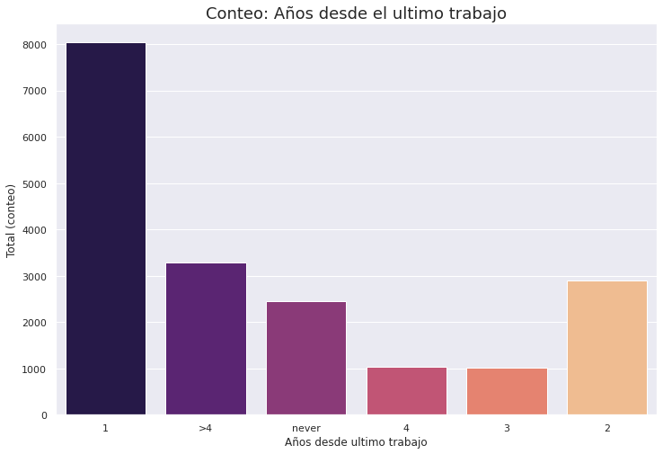

```python
plt.figure(figsize=(12,8))
ax=sns.countplot(x='last_new_job', data=df, palette='magma')
ax.set_title('Conteo: Años desde el ultimo trabajo',fontsize=18)
ax.set_ylabel('Total (conteo)')
ax.set_xlabel("Años desde ultimo trabajo")
plt.show()
```

```python
df['last_new_job'].value_counts()
```

```
1        8040
>4       3290
2        2900
never    2452
4        1029
3        1024
Name: last_new_job, dtype: int64
```

Para **last_new_job** se tiene el valor **>4** y **"never"**. Se puede dejar esta variable como categórica.

Aún se conservan 423 valores vacíos de esta variable _last_new*job* . Se procede a eliminarlos (todos los registros).

```python
df.dropna(inplace=True)
```

```python
df.isnull().sum()
```

```
enrollee_id               0
city                      0
city_development_index    0
gender                    0
relevent_experience       0
enrolled_university       0
education_level           0
major_discipline          0
experience                0
company_size              0
company_type              0
last_new_job              0
training_hours            0
target                    0
dtype: int64
```

```python
df.shape
```

```
(18735, 14)
```

##### **Distribución 'experience'**

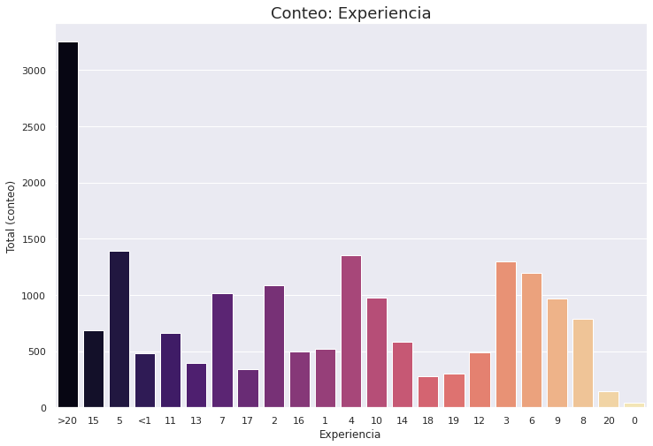

```python
plt.figure(figsize=(12,8))
ax= sns.countplot(x='experience', data=df, palette='magma')
ax.set_title('Conteo: Experiencia',fontsize=18)
ax.set_ylabel('Total (conteo)')
ax.set_xlabel("Experiencia")
```

```python
df['experience'].value_counts()
```

```
>20    3253
5      1396
4      1350
3      1296
6      1194
2      1090
7      1013
10      977
9       965
8       790
15      684
11      659
14      582
1       517
16      500
12      488
<1      484
13      394
17      340
19      299
18      276
20      147
0        41
Name: experience, dtype: int64
```

Todos los posibles valores son numéricos excepto >20 y < 1.

**Se asume que >20 es más de 20 pero menor que 21, dejando el valor en 20.5** , y que < 1 es 0

**NOTA IMPORTANTE:** Puede ser el caso de que solo se hayan tomado valores hasta mayor que 20 (incluye 21, 30,35, etc...). Sin embargo, no se tiene esa información del negocio y la decisión se toma de manera subjetiva.

```python
# solo dos valores: <1 y >20 difieren del formato entero
df['experience'] = df['experience'].apply(lambda x: '0' if x == '<1' else x)#se suman a los 65 que antes eran NaN
df['experience'] = df['experience'].apply(lambda x: '20.5' if x == '>20' else x)
#inconsistencia de formato categorico en company_size
df['company_size'] = df['company_size'].apply(lambda x: '10-49' if x == '10/49' else x)
```

Se procede a convertir las columnas deseadas a números (float)

```python
df['experience'] = df['experience'].astype(str).astype(float)
```

```python
df.head()
```

|  | enrollee_id | city | city_development_index | gender | relevent_experience | enrolled_university | education_level | major_discipline | experience | company_size | company_type | last_new_job | training_hours | target |
| --- | --- | --- | --- | --- | --- | --- | --- | --- | --- | --- | --- | --- | --- | --- |
| 0 | 8949 | city_103 | 0.920 | Male | Has relevent experience | no_enrollment | Graduate | STEM | 20.5 | 0 | Unknown | 1 | 36 | 1.0 |
| 1 | 29725 | city_40 | 0.776 | Male | No relevent experience | no_enrollment | Graduate | STEM | 15.0 | 50-99 | Pvt Ltd | >4 | 47 | 0.0 |
| 2 | 11561 | city_21 | 0.624 | Not respond | No relevent experience | Full time course | Graduate | STEM | 5.0 | 0 | Unknown | never | 83 | 0.0 |
| 3 | 33241 | city_115 | 0.789 | Not respond | No relevent experience | Unknown | Graduate | Business Degree | 0.0 | 0 | Pvt Ltd | never | 52 | 1.0 |
| 4 | 666 | city_162 | 0.767 | Male | Has relevent experience | no_enrollment | Masters | STEM | 20.5 | 50-99 | Funded Startup | 4 | 8 | 0.0 |

### **2.1 Análisis estadístico descriptivo de los datos.**

A continuación se realiza un análisis estadístico descriptivo de los datos, con el fin de encontrar características importantes y describir cuantitativamente los datos

Lo primero que se realiza es eliminar la columna **"enrolle_id"**, ya que no aporta ningún tipo de información valiosa a nuestro análisis.

```python
del df['enrollee_id']
df.head()
```

|  | city | city_development_index | gender | relevent_experience | enrolled_university | education_level | major_discipline | experience | company_size | company_type | last_new_job | training_hours | target |
| --- | --- | --- | --- | --- | --- | --- | --- | --- | --- | --- | --- | --- | --- |
| 0 | city_103 | 0.920 | Male | Has relevent experience | no_enrollment | Graduate | STEM | 20.5 | 0 | Unknown | 1 | 36 | 1.0 |
| 1 | city_40 | 0.776 | Male | No relevent experience | no_enrollment | Graduate | STEM | 15.0 | 50-99 | Pvt Ltd | >4 | 47 | 0.0 |
| 2 | city_21 | 0.624 | Not respond | No relevent experience | Full time course | Graduate | STEM | 5.0 | 0 | Unknown | never | 83 | 0.0 |
| 3 | city_115 | 0.789 | Not respond | No relevent experience | Unknown | Graduate | Business Degree | 0.0 | 0 | Pvt Ltd | never | 52 | 1.0 |
| 4 | city_162 | 0.767 | Male | Has relevent experience | no_enrollment | Masters | STEM | 20.5 | 50-99 | Funded Startup | 4 | 8 | 0.0 |

#### 2.1.1 Conteo de los tag objetivo.

A continuación, se revisa el cuál es el total de datos que se tienen para 0 y 1.

Tip:

0 –No busca un cambio de trabajo

1 – Sí busca un cambio de trabajo

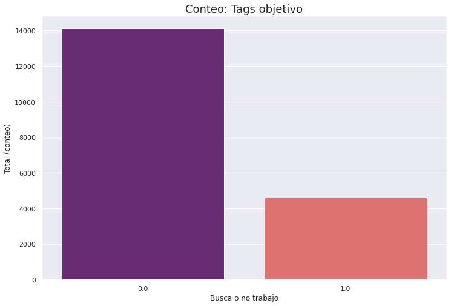

```python
plt.figure(figsize=(12,8))
ax= sns.countplot(x='target', data=df, palette='magma')
ax.set_title('Conteo: Tags objetivo',fontsize=18)
ax.set_ylabel('Total (conteo)')
ax.set_xlabel("Busca o no trabajo")
```

```python
df['target'].value_counts()
```

```
0.0    14112
1.0     4623
Name: target, dtype: int64
```

Se tiene un dataset desbalanceado. Esto puede afectar los resultados del modelo de predicción.

**Por ahora se continúa con la descripción de los datos y después se decide cómo tratar este tema**

#### 2.1.2 Medidas de tendencia central

Nota: se convierte la variable "experience" a numérica. Por lo cual, sería bueno volver a revisar los datos usando las medidas de tendencia central.

```python
df.describe()
```

|  | city_development_index | experience | training_hours | target |
| --- | --- | --- | --- | --- |
| count | 18735.000000 | 18735.000000 | 18735.000000 | 18735.000000 |
| mean | 0.830139 | 10.071284 | 65.493301 | 0.246757 |
| std | 0.122766 | 6.639487 | 60.101021 | 0.431136 |
| min | 0.448000 | 0.000000 | 1.000000 | 0.000000 |
| 25% | 0.743000 | 4.000000 | 23.000000 | 0.000000 |
| 50% | 0.910000 | 9.000000 | 47.000000 | 0.000000 |
| 75% | 0.920000 | 16.000000 | 88.000000 | 0.000000 |
| max | 0.949000 | 20.500000 | 336.000000 | 1.000000 |

- Para la variable **city_development_index** se tiene un promedio de 0.83 con una muy baja desviación estandar de 0.12, lo que indica una alta cercanía a la media y un promedio confiable.
- La **experience** tiene una alta desviación estandar al igual que **training_hours**

Se agrega una nueva variable al dataframe, simplemente para mejorar las visualizaciones.

```python
df['busca_empleo'] = df['target'].apply(lambda x: 'SI' if x == 1.0 else 'NO')
```

```python
df[['target','busca_empleo']].head()
```

|  | target | busca_empleo |
| --- | --- | --- |
| 0 | 1.0 | SI |
| 1 | 0.0 | NO |
| 2 | 0.0 | NO |
| 3 | 1.0 | SI |
| 4 | 0.0 | NO |

#### 2.1.3 ¿Cómo se distribuyen los datos?

##### **Género y búsqueda de trabajo**

```python
px.colors.sequential
```

```
<module '_plotly_utils.colors.sequential' from '/usr/local/lib/python3.7/dist-packages/_plotly_utils/colors/sequential.py'>
```

```python
px.histogram(df,
             x = 'gender',
             color = 'busca_empleo', barmode="group",
             title="Conteo de Hombres y mujeres vs Busqueda de trabajo",
             labels={
                 "gender":"Genero"
             })
```

[interactive chart not shown]

```python
px.histogram(df,
             x = 'gender',
             color = 'busca_empleo', barnorm="percent",
             labels={
                 "gender":"Genero"
             },
             title='Porcentaje: Busqueda de trabajo por genero')
```

[interactive chart not shown]

Si se hace referencia a valores absolutos, por supuesto se encuentra que los hombres son los más interesados en cambiar de trabajo debido a su conteo total (2990) vs las 323 mujeres. **Pero cuidado** si se compara solo el grupo (porcentajes) **resultan ser las mujeres las más interesadas en cambiar de trabajo**

- El 26% de las mujeres busca cambiar de trabajo frente al 22% de hombres.

##### **Experiencia relevante y deseo de cambiar de empleo**

```python
px.histogram(df,
             x = 'relevent_experience',
             color = 'busca_empleo', barnorm="percent",
             labels={
                 "relevent_experience":"Experiencia Relevante",
             },
             title='Porcentaje: Experiencia relevante & deseo de cambiar de empleo')
```

[interactive chart not shown]

Revisando la experiencia relevante no se evidencia que sea una variable muy influyente en el deseo de cambiar o no de trabajo. Las personas con experiencia relevante tienen menos interés de cambiar de trabajo (21%) frente al 33% de las personas sin experiencia relevante que sí desean cambiar de trabajo.

Sin embargo, la gran mayoría de ambos grupos de experiencia no están interesados en cambiar de trabajo.

##### **Distribución de la experiencia**

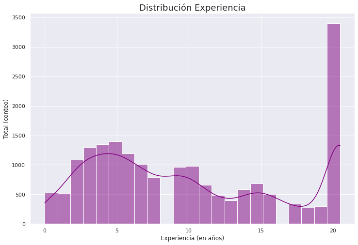

```python
plt.figure(figsize=(12,8))
ax= sns.histplot(df['experience'], kde=True,color="purple")
ax.set_title("Distribución Experiencia",fontsize=18)
ax.set_ylabel('Total (conteo)')
ax.set_xlabel("Experiencia (en años)")
```

Hay un pico para las personas con experiencia de 20 a más años, estas representan un alto porcentaje de la muestra. Lo que puede indicar que los cursos ofertados son de interés para personas de mayor experiencia. Si bien no es un dato que resulte importante para modelos predictivos no deja de ser una curiosidad.

##### **Densidad y distribución: indice de desarrollo (ciudad)**

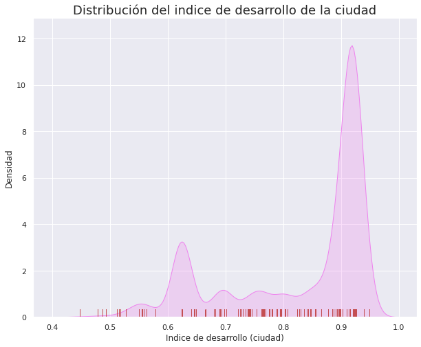

```python
plt.figure(figsize=(10,8))
sns.kdeplot(df["city_development_index"], shade=True, color="violet")
ax1= sns.rugplot(df['city_development_index'],color="r")
ax1.set_title("Distribución del indice de desarrollo de la ciudad",fontsize=18)
ax1.set_ylabel('Densidad')
ax1.set_xlabel("Indice de desarrollo (ciudad)")
plt.show()
```

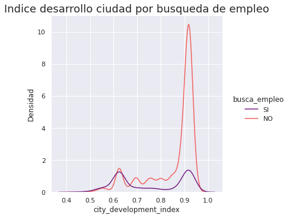

```python
plt.figure(figsize=(12,8))
ax= sns.displot(data=df, x="city_development_index", kind="kde",
            hue = 'busca_empleo', palette="magma")
plt.title("Indice desarrollo ciudad por busqueda de empleo", fontsize=18)
plt.ylabel("Densidad")
```

Hay una alta cantidad de valores en el rango de 0.9 city development index y otro pico más pequeño para un índice de desarrollo más bajo cercano a 0.6 - 0.65

- Como curiosidad donde hay picos de densidad en city development index también tenemos picos de búsqueda de empleo (SÍ) es decir tanto para un alto índice de desarrollo como para valores bajos.
- Se puede concluir que en valores bajos se busca mejorar la calidad de vida y en niveles altos al tener más oportunidades se está abierto a los cambios. **Sin embargo, cerca del índice de desarrollo 0.9 parece ser que este pico en los SÍ se debe a que también existe una enorme cantidad de datos para el NO.**

##### Análisis de la experiencia

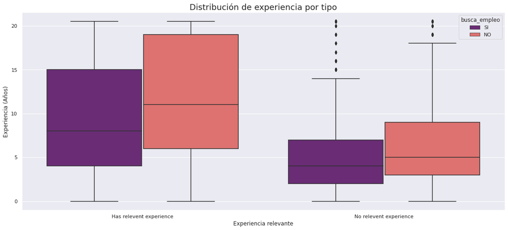

```python
plt.figure(figsize=(19,8))
exp_boxplot = sns.boxplot(x="relevent_experience",
                 y="experience",
                 data=df,
                 hue="busca_empleo",
                 palette='magma')

exp_boxplot.set_title('Distribución de experiencia por tipo', fontsize=18)
exp_boxplot.set_ylabel('Experiencia (Años)')
exp_boxplot.set_xlabel('Experiencia relevante')
exp_boxplot
```

En general la media y rangos de años de experiencia para las personas que buscan empleo es menor.

- Se puede inferir que **las personas con menos experiencia son más propensas a buscar un cambio de trabajo**.

##### **Distribución: Años desde el éltimo trabajo vs búsqueda de empleo**

```python
px.histogram(df,
             x = 'last_new_job',
             color = 'busca_empleo', barnorm="percent", barmode='group',
             title='Distribución Ultimo trabajo vs busqueda de empleo')
```

[interactive chart not shown]

Las personas que tienen entre 0 y 1 año de haber cambiado de trabajo están más dispuestas a hacerlo. A medida que se lleva más tiempo en un trabajo tiende a disminuir el interés por cambiar.

##### **Distribución: Nivel de educación vs búsqueda de empleo**

```python
px.histogram(df,
             x = 'education_level',
             color = 'busca_empleo', barnorm="percent", barmode='group',
             title='Distribución Educación vs busqueda de empleo')
```

[interactive chart not shown]

Las personas graduadas (pregrado) tienen más intenciones de cambiar de empleo. Es curioso por que los PhD suelen preferir conservar su empleo actual.

- Las personas de etapas tempranas de educación (expecto primaria) son más propensas a buscar un cambio de empleo.

##### **Análisis: Tamaño de la compañía y experiencia del candidato**

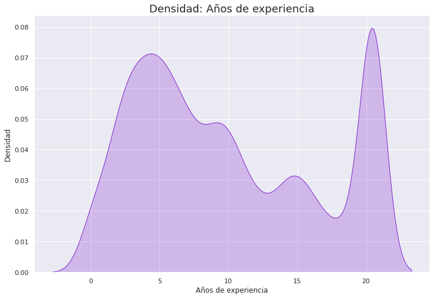

```python
plt.figure(figsize=(12,8))
ax=sns.kdeplot(df["experience"], shade=True, color="#8025D1")
ax.set_title('Densidad: Años de experiencia',fontsize=18)
ax.set_ylabel('Densidad')
ax.set_xlabel("Años de experiencia")
```

Se procede a agrupar los datos de años de experiencia de la siguiente forma:

- 0-5
- 5-10
- 10-15
- 15-20
- +20

```python
def convert(x):#función para convertir los datos a categorias
  val = None
  if x<5:
    val = '0-5'
  elif x >= 5 and x<10:
    val = '5-10'
  elif x >= 10 and x < 15:
    val = '10-15'
  elif x >= 15 and x < 20:
    val = '15-20'
  elif x >= 20:
    val = '+20'
  return val
```

```python
df['experience_cat']= df['experience'].apply(convert)
```

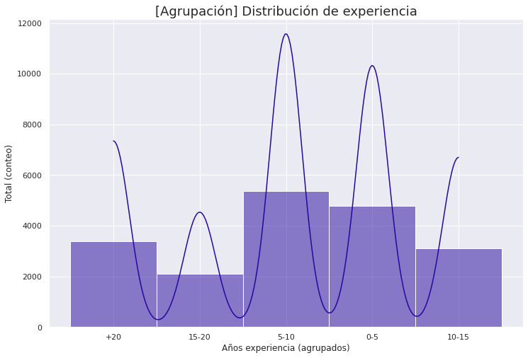

```python
plt.figure(figsize=(12,8))
ax= sns.histplot(df['experience_cat'], kde=True,color="#26069E")
ax.set_title("[Agrupación] Distribución de experiencia", fontsize=18)
ax.set_ylabel('Total (conteo)')
ax.set_xlabel("Años experiencia (agrupados)")
```

- En la primera gráfica se evidencia un gran pico cerca de 20 y más de 20 años de experiencia seguidos de valores pico cercanos entre los 5 y 10 años.

Posteriormente, al agrupar los datos dentro de un rango categórico se obtienen resultados similares. Hay 3 picos notables de edad siendo mayoría las personas entre 5 y 10 años de experiencia.

- Sin embargo se evidencia una variación, ya que ahora el rango de 15-10 o +20 representan muchos menos datos.

**Se descrta usar esta variable para futuras pruebas de hipótesis debido a que no se distribuye de manera normal**

```python
cross= pd.crosstab(df['company_size'].sort_index(ascending=True), df['experience'],normalize='index')
```

```python
cross=cross.set_index(pd.Index(['0','<10','10-49','50-99','100-500','500-999','1000-4999','5000-9999','10000+']),'company_size')
```

```python
cross
```

| experience | 0.0 | 1.0 | 2.0 | 3.0 | 4.0 | 5.0 | 6.0 | 7.0 | 8.0 | 9.0 | 10.0 | 11.0 | 12.0 | 13.0 | 14.0 | 15.0 | 16.0 | 17.0 | 18.0 | 19.0 | 20.0 | 20.5 |
| --- | --- | --- | --- | --- | --- | --- | --- | --- | --- | --- | --- | --- | --- | --- | --- | --- | --- | --- | --- | --- | --- | --- |
| 0 | 0.049546 | 0.046406 | 0.091940 | 0.097872 | 0.092812 | 0.081996 | 0.058793 | 0.052861 | 0.034368 | 0.040823 | 0.035764 | 0.026518 | 0.016399 | 0.013782 | 0.019365 | 0.022505 | 0.017446 | 0.013259 | 0.010816 | 0.011689 | 0.007153 | 0.157886 |
| <10 | 0.025070 | 0.028552 | 0.064067 | 0.066852 | 0.079387 | 0.085655 | 0.075209 | 0.047354 | 0.041086 | 0.057103 | 0.064067 | 0.042479 | 0.031337 | 0.023677 | 0.029248 | 0.035515 | 0.031337 | 0.011838 | 0.016017 | 0.015320 | 0.005571 | 0.123259 |
| 10-49 | 0.015760 | 0.011820 | 0.041371 | 0.054374 | 0.063042 | 0.063436 | 0.054768 | 0.055950 | 0.053191 | 0.063436 | 0.061466 | 0.038613 | 0.033097 | 0.022853 | 0.033491 | 0.046887 | 0.026793 | 0.021277 | 0.021277 | 0.019701 | 0.008668 | 0.188731 |
| 50-99 | 0.017571 | 0.010695 | 0.028266 | 0.042781 | 0.052712 | 0.054240 | 0.055768 | 0.045837 | 0.042017 | 0.048128 | 0.064171 | 0.036669 | 0.027502 | 0.026738 | 0.046600 | 0.053476 | 0.033613 | 0.023682 | 0.014515 | 0.022918 | 0.013751 | 0.238350 |
| 100-500 | 0.014573 | 0.014573 | 0.030151 | 0.046734 | 0.051759 | 0.068844 | 0.075377 | 0.053769 | 0.041709 | 0.055779 | 0.064824 | 0.038191 | 0.024623 | 0.025126 | 0.032663 | 0.041709 | 0.031658 | 0.023116 | 0.018593 | 0.020101 | 0.011055 | 0.215075 |
| 500-999 | 0.020435 | 0.021094 | 0.043177 | 0.067897 | 0.071523 | 0.080092 | 0.072841 | 0.053065 | 0.049769 | 0.056032 | 0.055043 | 0.039552 | 0.032301 | 0.022083 | 0.038563 | 0.039552 | 0.030653 | 0.020765 | 0.014832 | 0.013843 | 0.004614 | 0.152274 |
| 1000-4999 | 0.018519 | 0.018519 | 0.035880 | 0.045139 | 0.059028 | 0.060185 | 0.069444 | 0.064815 | 0.039352 | 0.057870 | 0.045139 | 0.034722 | 0.040509 | 0.032407 | 0.030093 | 0.050926 | 0.037037 | 0.018519 | 0.017361 | 0.023148 | 0.008102 | 0.193287 |
| 5000-9999 | 0.007207 | 0.025225 | 0.041441 | 0.027027 | 0.054054 | 0.066667 | 0.057658 | 0.070270 | 0.050450 | 0.045045 | 0.054054 | 0.041441 | 0.037838 | 0.028829 | 0.036036 | 0.034234 | 0.037838 | 0.023423 | 0.021622 | 0.018018 | 0.016216 | 0.205405 |
| 10000+ | 0.024276 | 0.033673 | 0.065779 | 0.072044 | 0.057948 | 0.079875 | 0.057948 | 0.060298 | 0.037588 | 0.054033 | 0.058731 | 0.039937 | 0.020360 | 0.021143 | 0.043070 | 0.038371 | 0.026625 | 0.018794 | 0.007048 | 0.014096 | 0.004699 | 0.163665 |

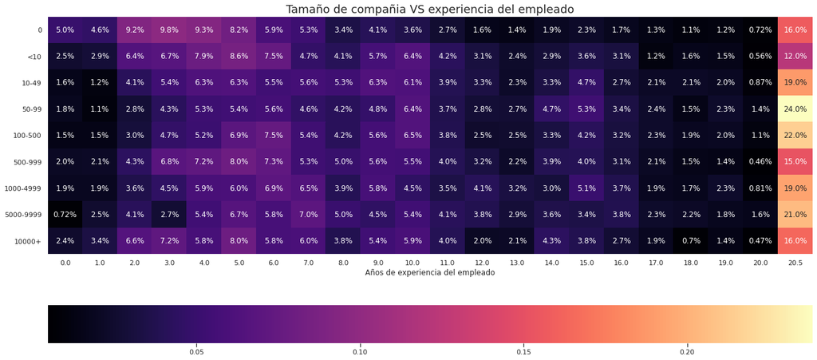

```python
plt.figure(figsize=(22,10))
ax= sns.heatmap(cross,annot=True,cbar_kws={"orientation": "horizontal"}, cmap="magma")
for t in ax.texts:
  porcent = float(t.get_text()) * 100
  text = str(round(porcent,2))
  t.set_text(text+"%")
ax.set_title('Tamaño de compañia VS experiencia del empleado', fontsize=18)
ax.set_xlabel("Años de experiencia del empleado")
plt.show()
```

**Tamaño de compañía vs Experiencia del empleado**

- Los empleados con más experiencia dominan en todos los tamaños de empresa.
- Las empresas pequeñas tienden a contratar a personas con menos experiencia. *esto se puede deber a que el rango salarial en esta área de experiencia es menor*

##### **Empleados que buscan y que no buscan trabajo vs tamaño de compañía y experiencia**

```python
find_job = df[df['busca_empleo']=='SI']
print(find_job.shape)
no_find_job = df[df['busca_empleo']=='NO']
print(no_find_job.shape)
```

```
(4623, 15)
(14112, 15)
```

```python
cross_find_job= pd.crosstab(find_job['company_size'], find_job['experience'],normalize='index')
```

```python
cross_find_job=cross_find_job.set_index(pd.Index(['0','<10','10-49','50-99','100-500','500-999','1000-4999','5000-9999','10000+']),'company_size')
```

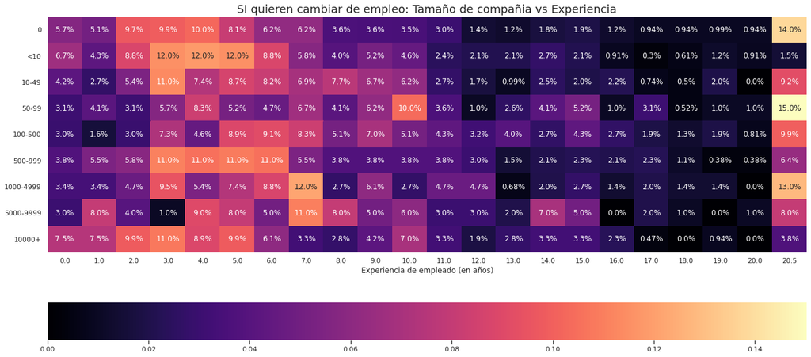

```python
plt.figure(figsize=(22,10))
ax= sns.heatmap(cross_find_job,annot=True,cbar_kws={"orientation": "horizontal"},
                cmap='magma')
for t in ax.texts:
  porcent = float(t.get_text()) * 100
  text = str(round(porcent,2))
  t.set_text(text+"%")
ax.set_title('SI quieren cambiar de empleo: Tamaño de compañia vs Experiencia',
         fontsize=18)
ax.set_xlabel("Experiencia de empleado (en años)")
plt.show()
```

**Las personas que tienen entre 2 y 7 años de experiencia parecen más interesadas en cambiar de empleo.**

**También se evidencia que algunos interesados en cambiar de empleo son las personas con más de 20 años de experiencia.**

```python
cross_nofind_job= pd.crosstab(no_find_job['company_size'], no_find_job['experience'],normalize='index')
```

```python
cross_nofind_job=cross_nofind_job.set_index(pd.Index(['0','<10','10-49','50-99','100-500','500-999','1000-4999','5000-9999','10000+']),'company_size')
```

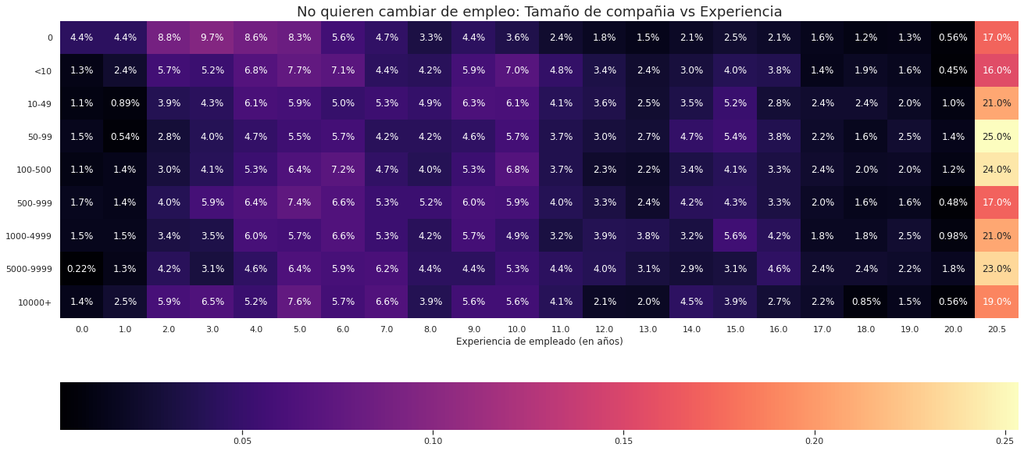

```python
plt.figure(figsize=(22,10))
ax= sns.heatmap(cross_nofind_job,annot=True,cbar_kws={"orientation": "horizontal"},
                cmap='magma')
for t in ax.texts:
  porcent = float(t.get_text()) * 100
  text = str(round(porcent,2))
  t.set_text(text+"%")
ax.set_title('No quieren cambiar de empleo: Tamaño de compañia vs Experiencia',fontsize=18)
ax.set_xlabel("Experiencia de empleado (en años)")
plt.show()
```

Sin embargo, se evidencia que son más los interesados por NO cambiar de trabajo después de más de 20 años de experiencia.

##### **Disciplina principal**

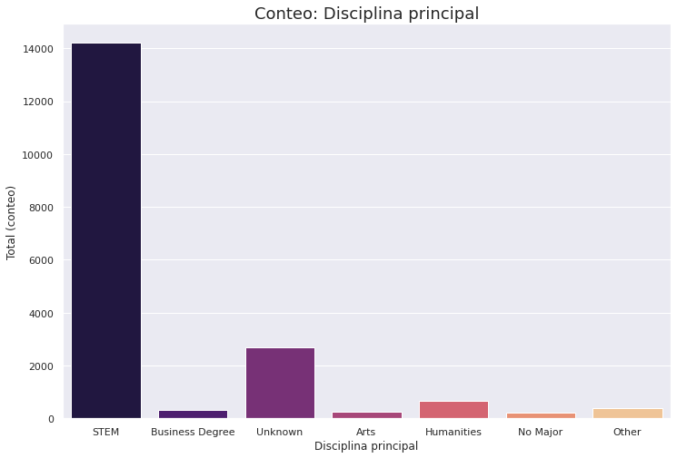

```python
plt.figure(figsize=(12,8))
ax= sns.countplot(x='major_discipline',data=df,palette='magma')
ax.set_title('Conteo: Disciplina principal',fontsize=18)
ax.set_ylabel('Total (conteo)')
ax.set_xlabel("Disciplina principal")
```

```python
px.histogram(df,
             x = 'major_discipline',
             color = 'busca_empleo', barnorm="percent",
             title='Porcentaje: Disciplina principal & deseo de cambiar de empleo')
```

[interactive chart not shown]

La mayoría de la muestra tiene una disciplina principal STEM (Ciencia, tecnología, ingeniería y matemáticas).

Sin embargo, la disciplina principal no parece influir en la decisión de buscar un cambio de empleo. Los porcentajes de participación (SÍ) son similares para todos los casos

Por último, a continuación se detalla cómo se distribuyen las horas de entrenamiento VS la búsqueda de empleo.

##### **Horas de entrenamiento vs búsqueda de empleo**

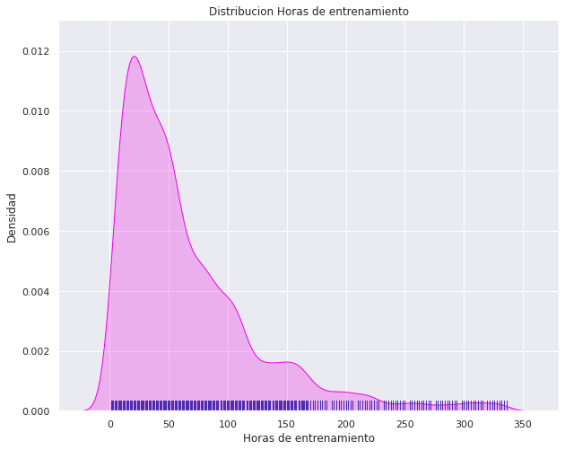

```python
plt.figure(figsize=(10,8))
sns.kdeplot(df["training_hours"], shade=True, color="#F100E3")
ax1=sns.rugplot(df['training_hours'],color="#492EAF")
ax1.set_title("Distribucion Horas de entrenamiento")
ax1.set_ylabel('Densidad')
ax1.set_xlabel("Horas de entrenamiento")
```

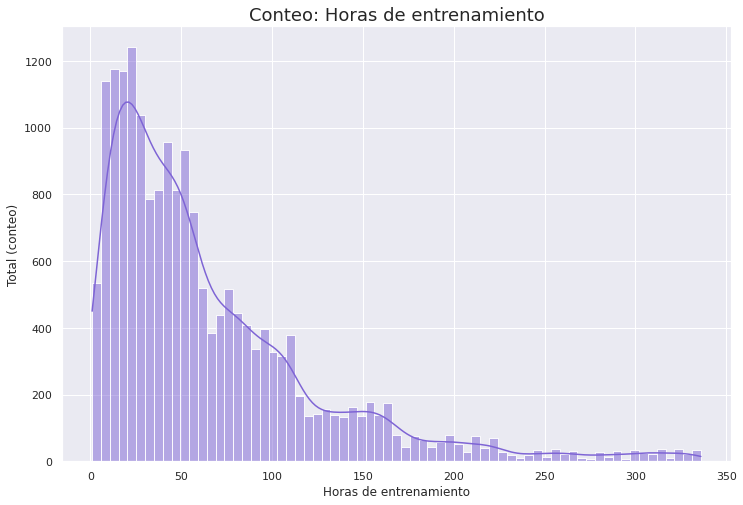

```python
plt.figure(figsize=(12,8))
ax= sns.histplot(df['training_hours'], kde=True,color="#7E64D5")
ax.set_title('Conteo: Horas de entrenamiento',fontsize=18)
ax.set_ylabel('Total (conteo)')
ax.set_xlabel("Horas de entrenamiento")
```

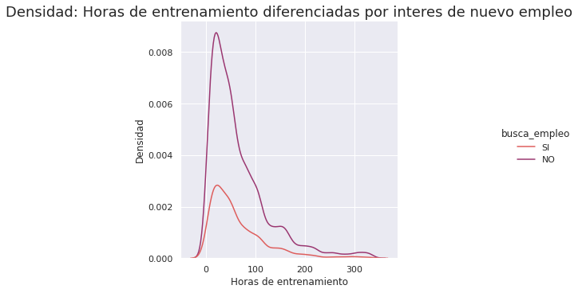

```python
plt.figure(figsize=(12,8))
ax1=sns.displot(data=df, x="training_hours", kind="kde",
            hue = 'busca_empleo', palette="flare")
plt.title("Densidad: Horas de entrenamiento diferenciadas por interes de nuevo empleo", fontsize=18)
plt.ylabel("Densidad")
plt.xlabel("Horas de entrenamiento")
```

Hay una relación interesante. Donde se muestra una mayor densidad de horas también se refleja más interés por cambiar de empleo.

Sin embargo, en este punto es donde hay una gran cantidad de datos y puede deberse simplemente a un sesgo.

## **3. Análisis de datos**

### 3.1 Preparación para el análisis

Antes de continuar, se procede a normalizar los datos numéricos y aplicar algunas transformaciones:

#### 3.1.1 Normalización

```python
df_norm = df[['city_development_index','experience','training_hours']].copy()
df_norm = (df_norm - df_norm.mean())/df_norm.std()#creamos una vista de df para operar la normalización
df_normalized = df.copy()
```

```python
df_normalized['city_development_index'] = df_norm['city_development_index']
df_normalized['experience'] = df_norm['experience']
df_normalized['training_hours'] = df_norm['training_hours']
```

#### 3.1.2 Obtener variables dummy

Antes de realizar análisis de correlación y demás pruebas, primero se obtinen los valores dummy para las variables categóricas de interés.

```python
df_normalized = df_normalized.loc[:,:'target'] #elimino columnas creadas para visualización
df_normalized.head()
```

|  | city | city_development_index | gender | relevent_experience | enrolled_university | education_level | major_discipline | experience | company_size | company_type | last_new_job | training_hours | target |
| --- | --- | --- | --- | --- | --- | --- | --- | --- | --- | --- | --- | --- | --- |
| 0 | city_103 | 0.731972 | Male | Has relevent experience | no_enrollment | Graduate | STEM | 1.570711 | 0 | Unknown | 1 | -0.490729 | 1.0 |
| 1 | city_40 | -0.440992 | Male | No relevent experience | no_enrollment | Graduate | STEM | 0.742334 | 50-99 | Pvt Ltd | >4 | -0.307704 | 0.0 |
| 2 | city_21 | -1.679122 | Not respond | No relevent experience | Full time course | Graduate | STEM | -0.763807 | 0 | Unknown | never | 0.291288 | 0.0 |
| 3 | city_115 | -0.335100 | Not respond | No relevent experience | Unknown | Graduate | Business Degree | -1.516877 | 0 | Pvt Ltd | never | -0.224510 | 1.0 |
| 4 | city_162 | -0.514303 | Male | Has relevent experience | no_enrollment | Masters | STEM | 1.570711 | 50-99 | Funded Startup | 4 | -0.956611 | 0.0 |

```python
df_dummies = pd.get_dummies(df_normalized, columns=['gender','relevent_experience','enrolled_university',
                                                     'education_level','major_discipline',
                                                     'company_size','company_type','last_new_job'],
                             prefix=['g_', 'rev_exp_','course_','edu_','disc_','com_size_','com_t_','job_'])
```

```python
df_dummies.head()
```

|  | city | city_development_index | experience | training_hours | target | g__Female | g__Male | g__Not respond | g__Other | rev_exp__Has relevent experience | rev_exp__No relevent experience | course__Full time course | course__Part time course | course__Unknown | course__no_enrollment | edu__Graduate | edu__High School | edu__Masters | edu__Phd | edu__Primary School | edu__Unknown | disc__Arts | disc__Business Degree | disc__Humanities | disc__No Major | disc__Other | disc__STEM | disc__Unknown | com_size__0 | … |
| --- | --- | --- | --- | --- | --- | --- | --- | --- | --- | --- | --- | --- | --- | --- | --- | --- | --- | --- | --- | --- | --- | --- | --- | --- | --- | --- | --- | --- | --- | --- |
| 0 | city_103 | 0.731972 | 1.570711 | -0.490729 | 1.0 | 0 | 1 | 0 | 0 | 1 | 0 | 0 | 0 | 0 | 1 | 1 | 0 | 0 | 0 | 0 | 0 | 0 | 0 | 0 | 0 | 0 | 1 | 0 | 1 | … |
| 1 | city_40 | -0.440992 | 0.742334 | -0.307704 | 0.0 | 0 | 1 | 0 | 0 | 0 | 1 | 0 | 0 | 0 | 1 | 1 | 0 | 0 | 0 | 0 | 0 | 0 | 0 | 0 | 0 | 0 | 1 | 0 | 0 | … |
| 2 | city_21 | -1.679122 | -0.763807 | 0.291288 | 0.0 | 0 | 0 | 1 | 0 | 0 | 1 | 1 | 0 | 0 | 0 | 1 | 0 | 0 | 0 | 0 | 0 | 0 | 0 | 0 | 0 | 0 | 1 | 0 | 1 | … |
| 3 | city_115 | -0.335100 | -1.516877 | -0.224510 | 1.0 | 0 | 0 | 1 | 0 | 0 | 1 | 0 | 0 | 1 | 0 | 1 | 0 | 0 | 0 | 0 | 0 | 0 | 1 | 0 | 0 | 0 | 0 | 0 | 1 | … |
| 4 | city_162 | -0.514303 | 1.570711 | -0.956611 | 0.0 | 0 | 1 | 0 | 0 | 1 | 0 | 0 | 0 | 0 | 1 | 0 | 0 | 1 | 0 | 0 | 0 | 0 | 0 | 0 | 0 | 0 | 1 | 0 | 0 | … |

```python
df_dummies.shape #50 columnas de caracter categorico y numerico
```

```
(18735, 50)
```

### 3.2 Pruebas estadísticas

##### 3.2.1 Prueba de normalidad Shapiro-Wilk

```python
def comprueba_normalidad(column):
  result= stats.shapiro(df_normalized[column])
  print("===== Prueba sobre ", column)
  if result[1] < 0.05:
    print("p-valor menor que significancia de 0.05")
    print("Se rechaza H0: Los datos No se distribuyen normalmente")
  else:
    print("p-valor mayor que significancia de 0.05")
    print("NO se rechaza H0: Los datos SI se distribuyen normalmente")
  print("W= ",result[0], "P-value= ", result[1])
  print("===========================================================")
```

```python
list_col_to_test = ['city_development_index','experience','training_hours']
for i in list_col_to_test:
  comprueba_normalidad(i)
```

```
===== Prueba sobre  city_development_index
p-valor menor que significancia de 0.05
Se rechaza H0: Los datos No se distribuyen normalmente
W=  0.7608340978622437 P-value=  0.0
===========================================================
===== Prueba sobre  experience
p-valor menor que significancia de 0.05
Se rechaza H0: Los datos No se distribuyen normalmente
W=  0.9054902195930481 P-value=  0.0
===========================================================
===== Prueba sobre  training_hours
p-valor menor que significancia de 0.05
Se rechaza H0: Los datos No se distribuyen normalmente
W=  0.822176456451416 P-value=  0.0
===========================================================
```

Cómo se analizó en el capítulo anterior a través de las visualizaciones, **ninguna de las columnas numéricas se distribuye de forma normal**.

#### 3.2.2 Prueba de varianza homogénea: Levene

Se realiza una prueba de varianza homogénea con los dos grupos que previamente habíamos separado. **quienes buscan trabajo** y **quienes no buscan trabajo**.

Tomando en cuenta la variable 'city_development_index' y separándola en dos grupos: quienes buscan trabajo y quienes no realizaremos la prueba.

```python
stat, pvalor = stats.levene(find_job['city_development_index'], no_find_job['city_development_index'])
if pvalor < 0.05:
  print(f'Las muestras no tienen varianzas homogéneas (no rechazar H0) p = {pvalor:.3f}')
else:
  print(f'Las muestras tienen varianza homogéneas (rechazar H0) p = {pvalor:.3f}')
```

```
Las muestras no tienen varianzas homogéneas (no rechazar H0) p = 0.000
```

Las muestras no tienen varianza homogénea y tampoco se distribuyen de forma normal, por lo cual se tendrá que usar el coeficiente de Spearman si es que se desea probar la significancia estadística.

#### 3.2.3 Correlación

Se verifica si existe correlación entre el 'target' y las variables númericas iniciales.

```python
df_normalized.corr()
```

|  | city_development_index | experience | training_hours | target |
| --- | --- | --- | --- | --- |
| city_development_index | 1.000000 | 0.331170 | 0.000458 | -0.339128 |
| experience | 0.331170 | 1.000000 | 0.000609 | -0.174355 |
| training_hours | 0.000458 | 0.000609 | 1.000000 | -0.019957 |
| target | -0.339128 | -0.174355 | -0.019957 | 1.000000 |

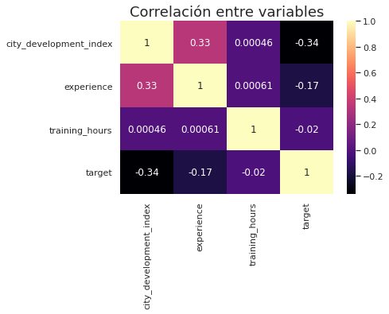

```python
ax=sns.heatmap(df_normalized.corr(),annot=True,cmap='magma')
ax.set_title('Correlación entre variables',fontsize=18)
```

Se grafica la relación que existe entre 'training hours' vs 'target'

#### 3.2.4 Gráfica: training_hours vs target

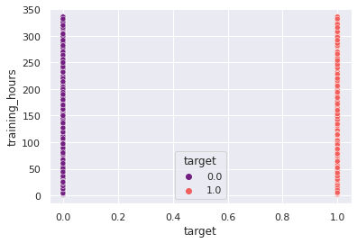

```python
sns.scatterplot(data=df, x="target", y="training_hours",      # Tono de color
                hue="target", palette="magma");   # Estilo del marcador.
```

No parece existir una relación notable a simple vista. Es decir, no se percibe, que por ejemplo, a más horas de entrenamiento se acumulen más puntos en búsqueda de trabajo.

#### Correlación de Spearman

Como los datos no se distribuyen bajo una normal ni tienen varianzas homogéneas, se debe utilizar la prueba de Spearman.

```python
def correlacion_spearmanr_con_significancia(a, b):
  coef, p = stats.spearmanr(a, b)
  print(f'Coeficiente de correlación de Spearman: {coef:.2f}')
  correlacion = False
  if p > 0.05:
    print(f'Las muestras no están correlacionadas (no rechazar H0) p = {p:.3f}')
  else:
    print(f'Las muestras están correlacionadas (rechazar H0) p = {p:.3f}')
    correlacion = True
  return correlacion
```

```python
list_col_to_test = ['city_development_index','experience','training_hours']
corr_list = list() #lista de variables correlacionadas final
for i in list_col_to_test:
  print(f"{i} VS target")
  correlacion= correlacion_spearmanr_con_significancia(df_normalized[i],df_normalized['target'])
  if correlacion:
    corr_list.append(i)
  print('============================')
print('============================================')
print('Variables correlacionadas con target: ', corr_list)
```

```
city_development_index VS target
Coeficiente de correlación de Spearman: -0.28
Las muestras están correlacionadas (rechazar H0) p = 0.000
============================
experience VS target
Coeficiente de correlación de Spearman: -0.18
Las muestras están correlacionadas (rechazar H0) p = 0.000
============================
training_hours VS target
Coeficiente de correlación de Spearman: -0.01
Las muestras no están correlacionadas (no rechazar H0) p = 0.109
============================
============================================
Variables correlacionadas con target:  ['city_development_index', 'experience']
```

Las variables 'city_development_index', 'experience' se relacion con target. Sin embargo la relacion es pequeña y en ambos casos negativa

Se comprueba si existe alguna otra relación relevante entre las variables y el 'target' usando nuestro dataset de variables dummy.

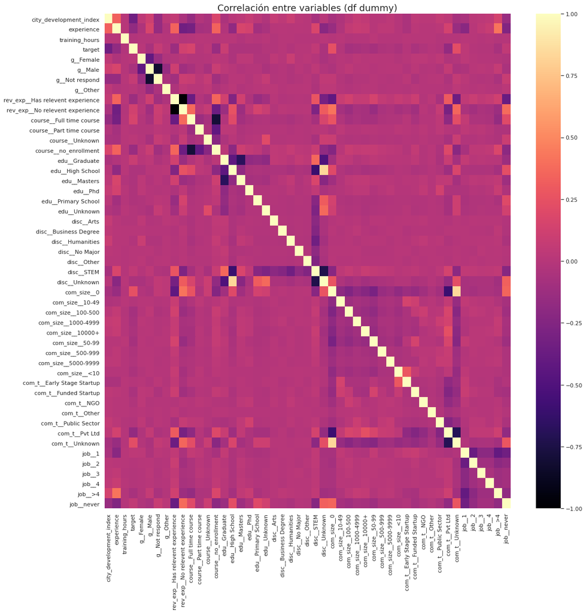

```python
plt.figure(figsize=(18,18))
ax=sns.heatmap(df_dummies.corr(),cmap='magma')
ax.set_title('Correlación entre variables (df dummy)',fontsize=18)
```

```python
corr_dummy = df_dummies.corr()#guardo tabla de correlacion
```

```python
corr_dummy_cols = list(corr_dummy.columns.values)#extraigo lista de columnas
corr_dummy_cols.remove('target')
print(len(corr_dummy))
```

```
49
```

```python
corr_list_2 = list() #lista de variables correlacionadas final
for i in corr_dummy_cols:
  print(f"{i} VS target")
  correlacion= correlacion_spearmanr_con_significancia(df_dummies[i],df_dummies['target'])
  if correlacion:
    corr_list_2.append(i)
  print('============================')
print('============================================')
print('Variables correlacionadas con target: ', corr_list_2)
print('total variables correlacionadas: ', len(corr_list_2))
```

```
city_development_index VS target
Coeficiente de correlación de Spearman: -0.28
Las muestras están correlacionadas (rechazar H0) p = 0.000
============================
experience VS target
Coeficiente de correlación de Spearman: -0.18
Las muestras están correlacionadas (rechazar H0) p = 0.000
============================
training_hours VS target
Coeficiente de correlación de Spearman: -0.01
Las muestras no están correlacionadas (no rechazar H0) p = 0.109
============================
g__Female VS target
Coeficiente de correlación de Spearman: 0.01
Las muestras no están correlacionadas (no rechazar H0) p = 0.194
============================
g__Male VS target
Coeficiente de correlación de Spearman: -0.07
Las muestras están correlacionadas (rechazar H0) p = 0.000
============================
g__Not respond VS target
Coeficiente de correlación de Spearman: 0.07
Las muestras están correlacionadas (rechazar H0) p = 0.000
============================
g__Other VS target
Coeficiente de correlación de Spearman: 0.00
Las muestras no están correlacionadas (no rechazar H0) p = 0.628
============================
rev_exp__Has relevent experience VS target
Coeficiente de correlación de Spearman: -0.13
Las muestras están correlacionadas (rechazar H0) p = 0.000
============================
rev_exp__No relevent experience VS target
Coeficiente de correlación de Spearman: 0.13
Las muestras están correlacionadas (rechazar H0) p = 0.000
============================
course__Full time course VS target
Coeficiente de correlación de Spearman: 0.15
Las muestras están correlacionadas (rechazar H0) p = 0.000
============================
```

[output cut: 140 more lines]

```
job__4 VS target
Coeficiente de correlación de Spearman: -0.01
Las muestras no están correlacionadas (no rechazar H0) p = 0.054
============================
job__>4 VS target
Coeficiente de correlación de Spearman: -0.07
Las muestras están correlacionadas (rechazar H0) p = 0.000
============================
job__never VS target
Coeficiente de correlación de Spearman: 0.05
Las muestras están correlacionadas (rechazar H0) p = 0.000
============================
============================================
Variables correlacionadas con target:  ['city_development_index', 'experience', 'g__Male', 'g__Not respond', 'rev_exp__Has relevent experience', 'rev_exp__No relevent experience', 'course__Full time course', 'course__Unknown', 'course__no_enrollment', 'edu__Graduate', 'edu__High School', 'edu__Maste…
total variables correlacionadas:  33
```

**Se tiene un total de 33** variables correlacionadas segun el coeficiente de correlación de Spearman.

Tip:

- Inicialmente tenemos 2 variables relacionadas con el 'target'

## **4. Modelado de datos**

De acuerdo con los resultados del análisis de correlación se realizan varias iteracciones para seleccionar el mejor modelo de regresión logística.

### **4.1 Model 1: Variables correlacionadas inicialmente**

Se utilizan las variables que inicialmente mostraron una correlación antes de obtener los valores dummy. Estas son 2:

- city_development_index
- experience

```python
model = sm.GLM.from_formula("target ~ city_development_index + experience", family=sm.families.Binomial(), data=df_normalized)
result = model.fit()
result.summary()
```

Generalized Linear Model Regression Results

| Dep. Variable: | target | No. Observations: | 18735 |
| --- | --- | --- | --- |
| Model: | GLM | Df Residuals: | 18732 |
| Model Family: | Binomial | Df Model: | 2 |
| Link Function: | logit | Scale: | 1.0000 |
| Method: | IRLS | Log-Likelihood: | -9411.1 |
| Date: | Fri, 26 Mar 2021 | Deviance: | 18822. |
| Time: | 00:04:31 | Pearson chi2: | 1.90e+04 |
| No. Iterations: | 4 |  |  |
| Covariance Type: | nonrobust |  |  |

|  | coef | std err | z | P>\|z\| | [0.025 | 0.975] |
| --- | --- | --- | --- | --- | --- | --- |
| Intercept | -1.2469 | 0.019 | -66.041 | 0.000 | -1.284 | -1.210 |
| city_development_index | -0.6718 | 0.018 | -38.173 | 0.000 | -0.706 | -0.637 |
| experience | -0.1990 | 0.020 | -9.890 | 0.000 | -0.238 | -0.160 |

Los resultados del reporte de clasificación y la matriz de confusión se muestran a continuación

```python
y_data = df_normalized[['target']]#etiquetas originales
```

```python
yhat = result.predict(df_normalized[["city_development_index","experience"]])
prediction = list(map(round, yhat)) #etiquetas predecidas con el modelo 1
```

```python
print(classification_report(y_data,prediction))
```

```
              precision    recall  f1-score   support

         0.0       0.80      0.93      0.86     14112
         1.0       0.59      0.30      0.40      4623

    accuracy                           0.78     18735
   macro avg       0.69      0.62      0.63     18735
weighted avg       0.75      0.78      0.75     18735
```

```python
# Matriz de confusion
cm = confusion_matrix(y_data, prediction)
print ("Confusion Matrix : \n", cm)

# Score o puntuación del model
print('Test accuracy = ', accuracy_score(y_data, prediction))
```

```
Confusion Matrix :
 [[13125   987]
 [ 3222  1401]]
Test accuracy =  0.7753402722177742
```

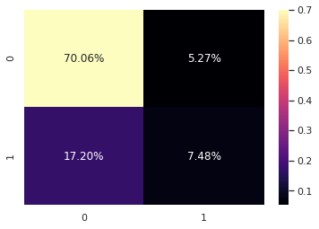

```python
sns.heatmap(cm/np.sum(cm), annot=True,fmt='.2%',cmap='magma')
ax.set_title('Matriz de confusión (df normalized)',fontsize=18)
```

##### **Comentarios del modelo 1.**

Los valores de P>|z| indican que todas las variables tienen relación con el 'target'

A pesar de que se obtiene un 'score' o efectividad del 78%, se encuentra al ver la matriz de confusión con un modelo que no es capaz de predecir los "SÍ" (valores 1)

- Esto se puede atribuir a que la muestra no está balanceada y se tienen unos pocos ejemplos de tipo 1.

**Lo que se quiere es lograr identificar mejor los tipo 1 es decir personas que SÍ buscan empleo**

Continuamos iterando...

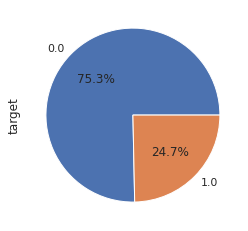

```python
df_normalized['target'].value_counts().plot.pie(autopct="%.1f%%");
```

Tan sólo el 24.7% de nuestros datos es "SI" (tipo 1).

### **Model 2: Todas las variables correlacionadas**

Se evidencia que resultados se obtienen al utilizar todas las variables correlacionadas según el calculo de la "Correlación de Spearman":

- city_development_index
- experience
- g__Male
- g__Not respond
- rev_exp__Has relevent experience
- rev_exp__No relevent experience
- course__Full time course
- course__Unknown
- course__no_enrollment
- edu__Graduate
- edu__High School
- edu__Masters
- edu__Phd
- edu__Primary School
- disc__Humanities
- disc__STEM
- disc__Unknown
- com_size__0
- com_size__100-500
- com_size__1000-4999
- com_size__10000+
- com_size__50-99
- com_size__500-999
- com_size__5000-9999
- com_size__<10
- com_t__Funded Startup
- com_t__NGO
- com_t__Public Sector
- com_t__Pvt Ltd
- com_t__Unknown
- job__1
- job__>4
- job__never

```python
x_data = df_dummies[corr_list_2]
y_data = df_dummies[['target']]
```

```python
model2 = sm.GLM(y_data,x_data, family=sm.families.Binomial(), data=df_dummies)
result2 = model2.fit()
result2.summary()
```

Generalized Linear Model Regression Results

| Dep. Variable: | target | No. Observations: | 18735 |
| --- | --- | --- | --- |
| Model: | GLM | Df Residuals: | 18702 |
| Model Family: | Binomial | Df Model: | 32 |
| Link Function: | logit | Scale: | 1.0000 |
| Method: | IRLS | Log-Likelihood: | -8653.8 |
| Date: | Fri, 26 Mar 2021 | Deviance: | 17308. |
| Time: | 00:04:32 | Pearson chi2: | 1.89e+04 |
| No. Iterations: | 5 |  |  |
| Covariance Type: | nonrobust |  |  |

|  | coef | std err | z | P>\|z\| | [0.025 | 0.975] |
| --- | --- | --- | --- | --- | --- | --- |
| city_development_index | -0.7152 | 0.019 | -36.904 | 0.000 | -0.753 | -0.677 |
| experience | -0.1777 | 0.026 | -6.968 | 0.000 | -0.228 | -0.128 |
| g__Male | -0.1867 | 0.072 | -2.605 | 0.009 | -0.327 | -0.046 |
| g__Not respond | -0.1263 | 0.078 | -1.617 | 0.106 | -0.279 | 0.027 |
| rev_exp__Has relevent experience | -2.0814 | 0.561 | -3.711 | 0.000 | -3.181 | -0.982 |
| rev_exp__No relevent experience | -1.8745 | 0.562 | -3.336 | 0.001 | -2.976 | -0.773 |
| course__Full time course | 0.2477 | 0.087 | 2.862 | 0.004 | 0.078 | 0.417 |
| course__Unknown | -0.0330 | 0.151 | -0.218 | 0.827 | -0.330 | 0.264 |
| course__no_enrollment | 0.0525 | 0.080 | 0.654 | 0.513 | -0.105 | 0.210 |
| edu__Graduate | 1.0447 | 0.535 | 1.952 | 0.051 | -0.004 | 2.094 |
| edu__High School | -0.0926 | 0.146 | -0.635 | 0.525 | -0.378 | 0.193 |
| edu__Masters | 0.8253 | 0.537 | 1.537 | 0.124 | -0.227 | 1.878 |
| edu__Phd | 0.6145 | 0.558 | 1.101 | 0.271 | -0.480 | 1.709 |
| edu__Primary School | -0.5661 | 0.226 | -2.508 | 0.012 | -1.009 | -0.124 |
| disc__Humanities | -0.0296 | 0.130 | -0.228 | 0.820 | -0.284 | 0.225 |
| disc__STEM | -0.0157 | 0.080 | -0.197 | 0.844 | -0.172 | 0.140 |
| disc__Unknown | 0.1043 | 0.524 | 0.199 | 0.842 | -0.923 | 1.132 |
| com_size__0 | 0.9566 | 0.099 | 9.627 | 0.000 | 0.762 | 1.151 |
| com_size__100-500 | -0.3197 | 0.091 | -3.512 | 0.000 | -0.498 | -0.141 |
| com_size__1000-4999 | -0.2277 | 0.109 | -2.084 | 0.037 | -0.442 | -0.014 |
| com_size__10000+ | -0.0278 | 0.095 | -0.293 | 0.769 | -0.213 | 0.158 |
| com_size__50-99 | -0.2453 | 0.086 | -2.847 | 0.004 | -0.414 | -0.076 |
| com_size__500-999 | -0.2319 | 0.119 | -1.941 | 0.052 | -0.466 | 0.002 |
| com_size__5000-9999 | -0.0695 | 0.138 | -0.505 | 0.613 | -0.339 | 0.200 |
| com_size__<10 | -0.3109 | 0.106 | -2.923 | 0.003 | -0.519 | -0.102 |
| com_t__Funded Startup | -0.3771 | 0.140 | -2.694 | 0.007 | -0.651 | -0.103 |
| com_t__NGO | -0.1472 | 0.162 | -0.909 | 0.363 | -0.465 | 0.170 |
| com_t__Public Sector | 0.1083 | 0.137 | 0.788 | 0.430 | -0.161 | 0.377 |
| com_t__Pvt Ltd | -0.2129 | 0.107 | -1.987 | 0.047 | -0.423 | -0.003 |
| com_t__Unknown | 0.0941 | 0.124 | 0.758 | 0.448 | -0.149 | 0.337 |
| job__1 | -0.1261 | 0.048 | -2.641 | 0.008 | -0.220 | -0.033 |
| job__>4 | -0.0345 | 0.065 | -0.535 | 0.593 | -0.161 | 0.092 |
| job__never | -0.6674 | 0.072 | -9.272 | 0.000 | -0.808 | -0.526 |

```python
yhat2 = result2.predict(df_dummies[corr_list_2])
prediction = list(map(round, yhat2)) #etiquetas predecidas con el modelo 2
```

```python
# Matriz de confusion
cm = confusion_matrix(y_data, prediction)
print ("Confusion Matrix : \n", cm)

# Score o puntuación del model
print('Test accuracy = ', accuracy_score(y_data, prediction))
```

```
Confusion Matrix :
 [[13228   884]
 [ 3384  1239]]
Test accuracy =  0.7721910862022952
```

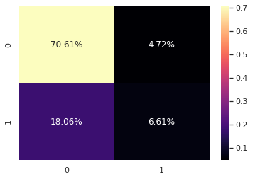

```python
sns.heatmap(cm/np.sum(cm), annot=True,fmt='.2%',cmap='magma')
ax.set_title('Matriz de confusión (df dummy)',fontsize=18)
```

Los resultados son similares a pesar de usar todo el conjunto de variables.

**A continuación se eliminan las variables poco significativas según el valor P>|z|** y **se realiza un balanceo de los datos**

```python
pred_vars = corr_list_2
#eliminando valores no significativos
pred_vars.remove('course__Unknown')
pred_vars.remove('course__no_enrollment')
pred_vars.remove('edu__High School')
pred_vars.remove('disc__STEM')
pred_vars.remove('disc__Unknown')
pred_vars.remove('com_size__10000+')
pred_vars.remove('com_size__5000-9999')
pred_vars.remove('com_t__NGO')
pred_vars.remove('com_t__Public Sector')
pred_vars.remove('com_t__Unknown')
pred_vars.remove('job__>4')
pred_vars.remove('edu__Masters')
pred_vars.remove('edu__Phd')
pred_vars.remove('disc__Humanities')
pred_vars.remove('g__Not respond')
print(pred_vars)
print(len(pred_vars))
```

```
['city_development_index', 'experience', 'g__Male', 'rev_exp__Has relevent experience', 'rev_exp__No relevent experience', 'course__Full time course', 'edu__Graduate', 'edu__Primary School', 'com_size__0', 'com_size__100-500', 'com_size__1000-4999', 'com_size__50-99', 'com_size__500-999', 'com_size_…
18
```

### 4.3 Modelo 3: Eliminando variables poco relacionadas

Ahora se realizar el modelo con las 18 variables que tienen un buen nivel de significancia según el valor P>|z|

```python
x_data = df_dummies[pred_vars]
y_data = df_dummies[['target']]
```

```python
model3 = sm.GLM(y_data,x_data, family=sm.families.Binomial(), data=df_dummies)
result3 = model3.fit()
result3.summary()
```

Generalized Linear Model Regression Results

| Dep. Variable: | target | No. Observations: | 18735 |
| --- | --- | --- | --- |
| Model: | GLM | Df Residuals: | 18717 |
| Model Family: | Binomial | Df Model: | 17 |
| Link Function: | logit | Scale: | 1.0000 |
| Method: | IRLS | Log-Likelihood: | -8712.4 |
| Date: | Fri, 26 Mar 2021 | Deviance: | 17425. |
| Time: | 00:04:33 | Pearson chi2: | 1.86e+04 |
| No. Iterations: | 5 |  |  |
| Covariance Type: | nonrobust |  |  |

|  | coef | std err | z | P>\|z\| | [0.025 | 0.975] |
| --- | --- | --- | --- | --- | --- | --- |
| city_development_index | -0.7205 | 0.019 | -37.921 | 0.000 | -0.758 | -0.683 |
| experience | -0.1461 | 0.024 | -6.095 | 0.000 | -0.193 | -0.099 |
| g__Male | -0.1104 | 0.041 | -2.698 | 0.007 | -0.191 | -0.030 |
| rev_exp__Has relevent experience | -1.4997 | 0.075 | -19.875 | 0.000 | -1.648 | -1.352 |
| rev_exp__No relevent experience | -1.3478 | 0.083 | -16.305 | 0.000 | -1.510 | -1.186 |
| course__Full time course | 0.1886 | 0.049 | 3.850 | 0.000 | 0.093 | 0.285 |
| edu__Graduate | 0.4895 | 0.041 | 11.976 | 0.000 | 0.409 | 0.570 |
| edu__Primary School | -0.8607 | 0.189 | -4.545 | 0.000 | -1.232 | -0.489 |
| com_size__0 | 0.9616 | 0.067 | 14.370 | 0.000 | 0.830 | 1.093 |
| com_size__100-500 | -0.3062 | 0.072 | -4.259 | 0.000 | -0.447 | -0.165 |
| com_size__1000-4999 | -0.1947 | 0.092 | -2.105 | 0.035 | -0.376 | -0.013 |
| com_size__50-99 | -0.2272 | 0.067 | -3.394 | 0.001 | -0.358 | -0.096 |
| com_size__500-999 | -0.1984 | 0.105 | -1.883 | 0.060 | -0.405 | 0.008 |
| com_size__<10 | -0.3186 | 0.092 | -3.474 | 0.001 | -0.498 | -0.139 |
| com_t__Funded Startup | -0.4178 | 0.109 | -3.843 | 0.000 | -0.631 | -0.205 |
| com_t__Pvt Ltd | -0.2677 | 0.054 | -4.992 | 0.000 | -0.373 | -0.163 |
| job__1 | -0.1214 | 0.044 | -2.781 | 0.005 | -0.207 | -0.036 |
| job__never | -0.7832 | 0.068 | -11.444 | 0.000 | -0.917 | -0.649 |

```python
yhat3 = result3.predict(x_data)
prediction = list(map(round, yhat3)) #etiquetas predecidas con el modelo 2
```

```python
# Matriz de confusion
cm = confusion_matrix(y_data, prediction)
print ("Confusion Matrix : \n", cm)

# Score o puntuación del model
print('Test accuracy = ', accuracy_score(y_data, prediction))
```

```
Confusion Matrix :
 [[13176   936]
 [ 3334  1289]]
Test accuracy =  0.7720843341339738
```

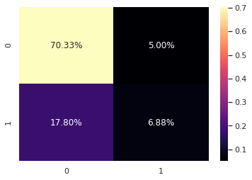

```python
sns.heatmap(cm/np.sum(cm), annot=True,fmt='.2%',cmap='magma')
ax.set_title('Matriz de confusión (df dummy)',fontsize=18)
```

```python
x_data.columns.values
```

```
array(['city_development_index', 'experience', 'g__Male',
       'rev_exp__Has relevent experience',
       'rev_exp__No relevent experience', 'course__Full time course',
       'edu__Graduate', 'edu__Primary School', 'com_size__0',
       'com_size__100-500', 'com_size__1000-4999', 'com_size__50-99',
       'com_size__500-999', 'com_size__<10', 'com_t__Funded Startup',
       'com_t__Pvt Ltd', 'job__1', 'job__never'], dtype=object)
```

### 4.4 Modelo 4: Quitando variables poco relacionadas restantes

```python
nw_vars = pred_vars
```

```python
nw_vars.remove('rev_exp__No relevent experience')
nw_vars.remove('com_size__500-999')
nw_vars.remove('course__Full time course') #no se correlaciona al revisar modelo v4
```

```python
x_data= df_dummies[nw_vars]
y_data= df_dummies[['target']]
```

```python
x_data.columns.values
```

```
array(['city_development_index', 'experience', 'g__Male',
       'rev_exp__Has relevent experience', 'edu__Graduate',
       'edu__Primary School', 'com_size__0', 'com_size__100-500',
       'com_size__1000-4999', 'com_size__50-99', 'com_size__<10',
       'com_t__Funded Startup', 'com_t__Pvt Ltd', 'job__1', 'job__never'],
      dtype=object)
```

```python
model4 = sm.GLM(y_data,x_data, family=sm.families.Binomial(), data=df_dummies)
result4 = model4.fit()
result4.summary()
```

Generalized Linear Model Regression Results

| Dep. Variable: | target | No. Observations: | 18735 |
| --- | --- | --- | --- |
| Model: | GLM | Df Residuals: | 18720 |
| Model Family: | Binomial | Df Model: | 14 |
| Link Function: | logit | Scale: | 1.0000 |
| Method: | IRLS | Log-Likelihood: | -8869.3 |
| Date: | Fri, 26 Mar 2021 | Deviance: | 17739. |
| Time: | 00:04:33 | Pearson chi2: | 1.88e+04 |
| No. Iterations: | 5 |  |  |
| Covariance Type: | nonrobust |  |  |

|  | coef | std err | z | P>\|z\| | [0.025 | 0.975] |
| --- | --- | --- | --- | --- | --- | --- |
| city_development_index | -0.7380 | 0.019 | -38.939 | 0.000 | -0.775 | -0.701 |
| experience | -0.1291 | 0.023 | -5.588 | 0.000 | -0.174 | -0.084 |
| g__Male | -0.3308 | 0.038 | -8.767 | 0.000 | -0.405 | -0.257 |
| rev_exp__Has relevent experience | -0.5513 | 0.043 | -12.955 | 0.000 | -0.635 | -0.468 |
| edu__Graduate | 0.2916 | 0.038 | 7.632 | 0.000 | 0.217 | 0.367 |
| edu__Primary School | -1.0882 | 0.190 | -5.741 | 0.000 | -1.460 | -0.717 |
| com_size__0 | 0.3122 | 0.047 | 6.583 | 0.000 | 0.219 | 0.405 |
| com_size__100-500 | -0.5868 | 0.066 | -8.844 | 0.000 | -0.717 | -0.457 |
| com_size__1000-4999 | -0.5280 | 0.088 | -6.029 | 0.000 | -0.700 | -0.356 |
| com_size__50-99 | -0.4869 | 0.061 | -7.957 | 0.000 | -0.607 | -0.367 |
| com_size__<10 | -0.6523 | 0.088 | -7.440 | 0.000 | -0.824 | -0.480 |
| com_t__Funded Startup | -0.7803 | 0.106 | -7.342 | 0.000 | -0.989 | -0.572 |
| com_t__Pvt Ltd | -0.6871 | 0.046 | -15.034 | 0.000 | -0.777 | -0.598 |
| job__1 | -0.3323 | 0.041 | -8.040 | 0.000 | -0.413 | -0.251 |
| job__never | -1.0656 | 0.066 | -16.148 | 0.000 | -1.195 | -0.936 |

```python
yhat4 = result4.predict(x_data)
prediction = list(map(round, yhat4)) #etiquetas predecidas con el modelo 4
```

```python
# Matriz de confusion
cm = confusion_matrix(y_data, prediction)
print ("Confusion Matrix : \n", cm)

# Score o puntuación del model
print('Test accuracy = ', accuracy_score(y_data, prediction))
```

```
Confusion Matrix :
 [[12981  1131]
 [ 3158  1465]]
Test accuracy =  0.7710701894849212
```

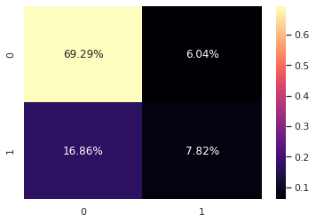

```python
sns.heatmap(cm/np.sum(cm), annot=True,cmap='magma', fmt='.2%')
ax.set_title('Matriz de confusión (df dummy)',fontsize=18)
```

### 4.5 Comentarios sobre los anteriores modelos

El modelo parece bueno. Con una efectividad entre el 77% y 78% . Sin embargo no lo es. Se ha modificado la ecuación en varias oportunidades y sin embargo el resultado es casi el mismo: **No es capaz de identificar eficazmente los "1 - SI" (personas interesadas en un nuevo empleo)**.

- Esto se debe a la baja cantidad de ejemplos "1 - SÍ" con los que cuenta la muestra utilizada.

```python
df_dummies['target'].value_counts()
```

```
0.0    14112
1.0     4623
Name: target, dtype: int64
```

```python
df_dummies.shape
```

```
(18735, 50)
```

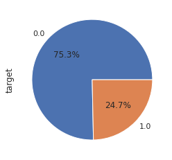

```python
df_dummies['target'].value_counts().plot.pie(autopct='%1.1f%%')
```

Menos del 25% de los datos corresponden a la etiqueta 1.

### 4.6 Modelo 5: Aplicando oversampling para balancear los datos

A continuación se realiza una última iteración del modelo, aplicando una técnica de oversampling o "sobre muestreo" conocida como SMOTE, una de las técnicas más utilizadas para tratar con datos desbalanceados.

Una pequeña explicación de cómo funciona:

*".. SMOTE selecciona primero una instancia de clase minoritaria al azar y encuentra sus vecinos de clase minoritaria más cercanos. A continuación, la instancia sintética se crea eligiendo uno de los vecinos k más cercanos b al azar y conectando a y b para formar un segmento de línea en el espacio de entidades. Las instancias sintéticas se generan como una combinación convexa de las dos instancias elegidas a y b."*

*Info adicional aquí:* https://machinelearningmastery.com/smote-oversampling-for-imbalanced-classification/

Hay que tener en cuenta de que los "1 - SI" son menos comunes.

Por tanto con el fin de no desviarse aún más de los datos reales se realiza un oversampling donde los "1 - SI" representen el 40% del total mientras que los "0-NO" el 60%

```python
#SMOTENC permite trabajar con variables categoricas
#Recibe la lista de indices donde existen variables categoricas
smo = SMOTENC(random_state=3,sampling_strategy=0.68,categorical_features=[2,3,4,5,6,7,8,9,10,11,12,13,14])
x_data_res, y_data_res = smo.fit_sample(x_data, y_data)#usamos mismo set de variables predictoras que en el modelo 4
```

```python
counter = Counter(y_data_res)
print("Nueva distribución del 'target':", counter)
```

```
Nueva distribución del 'target': Counter({0.0: 14112, 1.0: 9596})
```

```python
x_data_res = pd.DataFrame(x_data_res, columns=x_data.columns)#convertimos nuevamente a dataframe
y_data_res = pd.DataFrame(y_data_res, columns=y_data.columns)
```

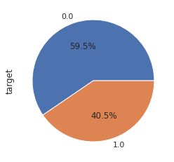

```python
y_data_res['target'].value_counts().plot.pie(autopct='%1.1f%%')
```

La muestra ahora se encuentra mejor balanceada. Con estos datos se entrena un nuevo modelo a continuación:

```python
#reajustamos las columnas categoricas a enteros ==> 0.0 -> 0
names_col_cat = x_data_res.iloc[:,2:].columns.values
for i in names_col_cat:
  x_data_res[i] = x_data_res[i].astype(float).astype(int)
```

```python
x_data_res
```

|  | city_development_index | experience | g__Male | rev_exp__Has relevent experience | edu__Graduate | edu__Primary School | com_size__0 | com_size__100-500 | com_size__1000-4999 | com_size__50-99 | com_size__<10 | com_t__Funded Startup | com_t__Pvt Ltd | job__1 | job__never |
| --- | --- | --- | --- | --- | --- | --- | --- | --- | --- | --- | --- | --- | --- | --- | --- |
| 0 | 0.731972 | 1.570711 | 1 | 1 | 1 | 0 | 1 | 0 | 0 | 0 | 0 | 0 | 0 | 1 | 0 |
| 1 | -0.440992 | 0.742334 | 1 | 0 | 1 | 0 | 0 | 0 | 0 | 1 | 0 | 0 | 1 | 0 | 0 |
| 2 | -1.679122 | -0.763807 | 0 | 0 | 1 | 0 | 1 | 0 | 0 | 0 | 0 | 0 | 0 | 0 | 1 |
| 3 | -0.335100 | -1.516877 | 0 | 0 | 1 | 0 | 1 | 0 | 0 | 0 | 0 | 0 | 1 | 0 | 1 |
| 4 | -0.514303 | 1.570711 | 1 | 1 | 0 | 0 | 0 | 0 | 0 | 1 | 0 | 1 | 0 | 0 | 0 |
| ... | ... | ... | ... | ... | ... | ... | ... | ... | ... | ... | ... | ... | ... | ... | ... |
| 23703 | -1.679122 | -1.172161 | 1 | 1 | 0 | 0 | 0 | 0 | 1 | 0 | 0 | 0 | 1 | 1 | 0 |
| 23704 | -1.679122 | 1.568500 | 0 | 1 | 0 | 0 | 0 | 0 | 0 | 0 | 0 | 0 | 1 | 1 | 0 |
| 23705 | -1.679122 | -0.652707 | 1 | 1 | 1 | 0 | 0 | 0 | 0 | 1 | 0 | 0 | 0 | 1 | 0 |
| 23706 | 0.731972 | -0.311964 | 1 | 1 | 1 | 0 | 1 | 0 | 0 | 0 | 0 | 0 | 0 | 1 | 0 |
| 23707 | 0.731972 | -0.050487 | 0 | 0 | 1 | 0 | 1 | 0 | 0 | 0 | 0 | 0 | 0 | 0 | 0 |

23708 rows × 15 columns

```python
model5 = sm.GLM(y_data_res,x_data_res, family=sm.families.Binomial())
result5 = model5.fit()
result5.summary()
```

Generalized Linear Model Regression Results

| Dep. Variable: | target | No. Observations: | 23708 |
| --- | --- | --- | --- |
| Model: | GLM | Df Residuals: | 23693 |
| Model Family: | Binomial | Df Model: | 14 |
| Link Function: | logit | Scale: | 1.0000 |
| Method: | IRLS | Log-Likelihood: | -13129. |
| Date: | Fri, 26 Mar 2021 | Deviance: | 26257. |
| Time: | 00:04:52 | Pearson chi2: | 2.44e+04 |
| No. Iterations: | 5 |  |  |
| Covariance Type: | nonrobust |  |  |

|  | coef | std err | z | P>\|z\| | [0.025 | 0.975] |
| --- | --- | --- | --- | --- | --- | --- |
| city_development_index | -0.7621 | 0.016 | -48.572 | 0.000 | -0.793 | -0.731 |
| experience | -0.1569 | 0.019 | -8.444 | 0.000 | -0.193 | -0.120 |
| g__Male | -0.1915 | 0.031 | -6.149 | 0.000 | -0.252 | -0.130 |
| rev_exp__Has relevent experience | -0.3126 | 0.036 | -8.805 | 0.000 | -0.382 | -0.243 |
| edu__Graduate | 0.3973 | 0.031 | 12.811 | 0.000 | 0.337 | 0.458 |
| edu__Primary School | -1.5644 | 0.175 | -8.934 | 0.000 | -1.908 | -1.221 |
| com_size__0 | 0.7676 | 0.039 | 19.455 | 0.000 | 0.690 | 0.845 |
| com_size__100-500 | -0.4635 | 0.052 | -8.848 | 0.000 | -0.566 | -0.361 |
| com_size__1000-4999 | -0.3918 | 0.069 | -5.712 | 0.000 | -0.526 | -0.257 |
| com_size__50-99 | -0.3683 | 0.048 | -7.596 | 0.000 | -0.463 | -0.273 |
| com_size__<10 | -0.6295 | 0.071 | -8.895 | 0.000 | -0.768 | -0.491 |
| com_t__Funded Startup | -0.7255 | 0.086 | -8.417 | 0.000 | -0.894 | -0.557 |
| com_t__Pvt Ltd | -0.4394 | 0.038 | -11.601 | 0.000 | -0.514 | -0.365 |
| job__1 | -0.2806 | 0.033 | -8.429 | 0.000 | -0.346 | -0.215 |
| job__never | -1.0024 | 0.054 | -18.599 | 0.000 | -1.108 | -0.897 |

```python
yhat5 = result5.predict(x_data_res)
prediction = list(map(round, yhat5)) #etiquetas predecidas con el modelo 5
```

```python
# Matriz de confusion
cm = confusion_matrix(y_data_res, prediction)
print ("Confusion Matrix : \n", cm)

# Score o puntuación del model
print('Test accuracy = ', accuracy_score(y_data_res, prediction))
```

```
Confusion Matrix :
 [[11352  2760]
 [ 3679  5917]]
Test accuracy =  0.7284039142905349
```

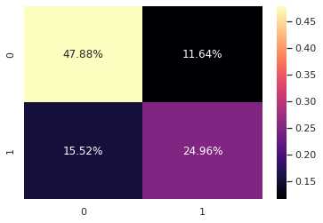

```python
sns.heatmap(cm/np.sum(cm), annot=True,cmap='magma',fmt='.2%')
ax.set_title('Matriz de confusión (df dummy)',fontsize=18)
```

##### Comentarios sobre el modelo 5

Hay una notable mejoría respecto a la capacidad del modelo para detectar los “1 - SI” y en general obtenemos resultados buenos en la diagonal.

Sin embargo la efectividad general se redujo de un 77% de anteriores modelos a un 72%

- Al agregar muestras sintéticas a los datos también se agrega un porcentaje de error.

Por otro lado el método **SMOTE agrega datos teniendo en cuenta los k-vecinos cercanos pero cuando los datos son similares entre ambas etiquetas (1 - SI y 0 - NO) estos “clusters” no son tan claros** y se presenta sobreposición de datos, lo que termina afectando aún más el modelo.

**El modelo 5 resulta efectivo para detectar los SÍ, pero las muestras sintéticas pueden no representar la realidad de los datos del negocio**